# Tutorial ANOVA de uma via para plano amostral AC1

Iara Passos, Júlia Vargas, Luiza Dalmolin, Vitória Garcia

2024-02-04

# Descrição do banco escolhido

A base de dados escolhida contêm os crimes registrados na cidade de Los Angeles de janeiro de 2020 a dezembro de 2023. O banco original pode ser encontrado no seguinte link: https://www.kaggle.com/datasets/asaniczka/crimes-in-los-angeles-2020-2023/data

As informações sobre cada crime registrado são:

| Variável | Descrição | Tipo |
| --- | --- | --- |
| division_number | número da divisão da polícia que registrou o crime | categórica |
| date_reported | data em que o crime foi reportado | data |
| date_occurred | data em que o crime ocorreu | data |
| area | código área em que o crime ocorreu | categórica |
| area_name | área em que o crime ocorreu | categórica |
| reporting_district | distrito em que o crime foi reportado | categórica |
| part | número da parte do crime | categórica |
| crime_code | código do tipo de crime primário | categórica |
| crime_description | descrição do crime primário | categórica |
| modus_operandi | código modus operanti do crime | categórica |
| victim_age | idade da vítima do crime | numérica |
| victim_sex | sexo da vítima do crime | categórica |
| victim_descent | etnia da vítima | categórica |
| premise_code | código do tipo de local em que o crime ocorreu | categórica |
| premise_description | descrição do tipo de local em que o crime ocorreu | categórica |
| weapon_code | código do tipo de arma utilizada no crime | categórica |
| weapon_description | descrição do tipo de arma utilizada no crime | categórica |
| status | código do status do crime | categórica |
| status_description | descrição do status do crime | categórica |
| crime_code_1 | código 1 adicional do crime, se aplicável | categórica |
| crime_code_2 | código 2 adicional do crime, se aplicável | categórica |
| crime_code_3 | código 3 adicional do crime, se aplicável | categórica |
| crime_code_4 | código 4 adicional do crime, se aplicável | categórica |
| location | endereço em que o crime ocorreu | texto |
| cross_street | a rua que cruza o endereço em que o crime ocorreu (se aplicável) | texto |
| latitude | latitude em que o crime ocorreu | numérica |
| longitude | longitude em que o crime ocorreu | numérica |

Para esse tutorial, usaremos o bairro como conglomerados, o tipo de crime como variável categórica e a idade da vítima como variável numérica a ser analisada. No entanto, será necessário realizar alguns tratamentos na base antes de continuarmos.

# Tratamento do banco e definição do banco final

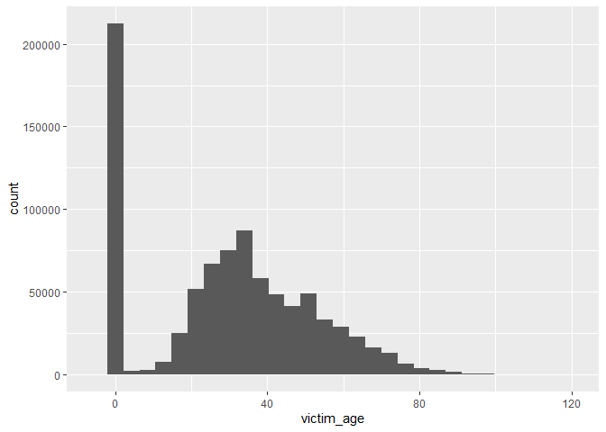

```r
Crime_Data_from_2020_to_Present %>%
  ggplot(aes(x = victim_age)) + geom_histogram()
```

```r
range(Crime_Data_from_2020_to_Present$victim_age)
```

```
## [1]  -3 120
```

```r
Crime_Data_from_2020_to_Present %>%
  filter(victim_age <= 0) %>%
  group_by(victim_age) %>%
  count()
```

```
## # A tibble: 4 × 2
## # Groups:   victim_age [4]
##   victim_age      n
##        <dbl>  <int>
## 1         -3      1
## 2         -2     13
## 3         -1     60
## 4          0 211842
```

```r
Crime_Data_from_2020_to_Present %>%
  filter(victim_age == 0) %>%
  group_by(crime_description) %>%
  count()
```

```
## # A tibble: 133 × 2
## # Groups:   crime_description [133]
##    crime_description                                            n
##    <chr>                                                    <int>
##  1 ARSON                                                      996
##  2 ASSAULT WITH DEADLY WEAPON ON POLICE OFFICER               770
##  3 ASSAULT WITH DEADLY WEAPON, AGGRAVATED ASSAULT            1827
##  4 ATTEMPTED ROBBERY                                          566
##  5 BATTERY - SIMPLE ASSAULT                                   857
##  6 BATTERY ON A FIREFIGHTER                                    75
##  7 BATTERY POLICE (SIMPLE)                                   1685
##  8 BATTERY WITH SEXUAL CONTACT                                 36
##  9 BEASTIALITY, CRIME AGAINST NATURE SEXUAL ASSLT WITH ANIM     5
## 10 BIGAMY                                                       3
## # ℹ 123 more rows
```

```r
Crime_Data_from_2020_to_Present %>%
  group_by(victim_sex) %>%
  count()
```

```
## # A tibble: 6 × 2
## # Groups:   victim_sex [6]
##   victim_sex      n
##   <chr>       <int>
## 1 -               1
## 2 F          313468
## 3 H              93
## 4 M          351362
## 5 X           75420
## 6 <NA>       112606
```

```r
Crime_Data_from_2020_to_Present %>%
  group_by(victim_descent) %>%
  count() %>%
  arrange(n)
```

```
## # A tibble: 21 × 2
## # Groups:   victim_descent [21]
##    victim_descent     n
##    <chr>          <int>
##  1 -                  2
##  2 S                 46
##  3 L                 56
##  4 G                 63
##  5 D                 66
##  6 U                170
##  7 P                229
##  8 Z                426
##  9 I                805
## 10 V                893
## # ℹ 11 more rows
```

Com base nos dados do censo da cidade de Los Angeles de 2020 verificamos a seguinte distribuição étnica:

| Grupo étnico | Proporção |
| --- | --- |
| Hispanic/Latino | 46.9% |
| White (alone, not Hispanic or Latino) | 28.9% |
| Asian (alone) | 11.7% |
| Black or African American | 8.3% |
| Two or more races | 3.3% |
| Other (alone) | 0.7% |
| Native American (alone) | 0.2% |
| Native Hawaiian and Other Pacific Islander (alone) | 0.1% |

Considerando as categorias apresentadas no banco e a proporção populacional, supomos que:

- H - Hispanic
- W - White
- A - Asian
- B - Black
- O - Other

Analisando o gráfico e as tabelas, definimos:

- retirar vítimas com idade menor do que 0 e 120 anos, pois possivelmente se trata de missing no banco;
- retirar vítimas com idade 0, pois possivelmente se trata de missing no banco, dada a natureza dos crimes;
- retirar vítimas com idade abaixo de 16 anos, por não haver confiança nos dados inseridos, analisando também a natureza dos crimes.
- retirar vítimas que não tem sexo F (female) ou M (male)
- retirar vítimas que não tem etnia das categorias H, W, A, B ou O

```r
amostra <- Crime_Data_from_2020_to_Present %>%
  select("date_reported", "date_occurred", "area", "area_name", "crime_code",
         "crime_description", "victim_age", "victim_sex", "victim_descent", "crime_code_1") %>%
  filter(victim_age >= 16) %>%
  filter(victim_age != 120) %>%
  filter(victim_sex == "F" | victim_sex == "M") %>%
  filter(victim_descent == "H" | victim_descent == "W" | victim_descent == "A" | victim_descent == "B" | victim_descent == "O" )

contagem <- amostra %>%
  group_by(crime_description) %>%
  count()

contagem %>%
  arrange(n)
```

```
## # A tibble: 135 × 2
## # Groups:   crime_description [135]
##    crime_description                                      n
##    <chr>                                              <int>
##  1 DISHONEST EMPLOYEE ATTEMPTED THEFT                     1
##  2 LYNCHING                                               1
##  3 LYNCHING - ATTEMPTED                                   1
##  4 CHILD ABANDONMENT                                      2
##  5 DRUGS, TO A MINOR                                      2
##  6 FIREARMS EMERGENCY PROTECTIVE ORDER (FIREARMS EPO)     2
##  7 FIREARMS RESTRAINING ORDER (FIREARMS RO)               2
##  8 GRAND THEFT / AUTO REPAIR                              2
##  9 PETTY THEFT - AUTO REPAIR                              2
## 10 THEFT, COIN MACHINE - ATTEMPT                          2
## # ℹ 125 more rows
```

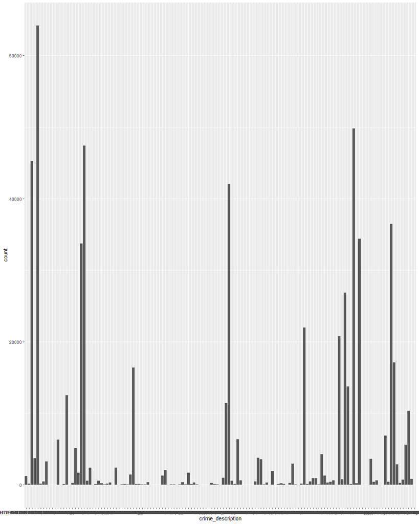

```r
amostra %>%
  ggplot(aes(x = crime_description)) + geom_bar()
```

Por haver muitos crimes com pouca frequência, optamos por retirar aqueles com menos de 10000 casos.

```r
tipos <- contagem %>%
  filter(n >= 10000) %>%
  select(crime_description)

amostra_tipos <- amostra %>%
  filter(crime_description %in% tipos$crime_description)
```

Resultando na seguinte distribuição na idade das vítimas:

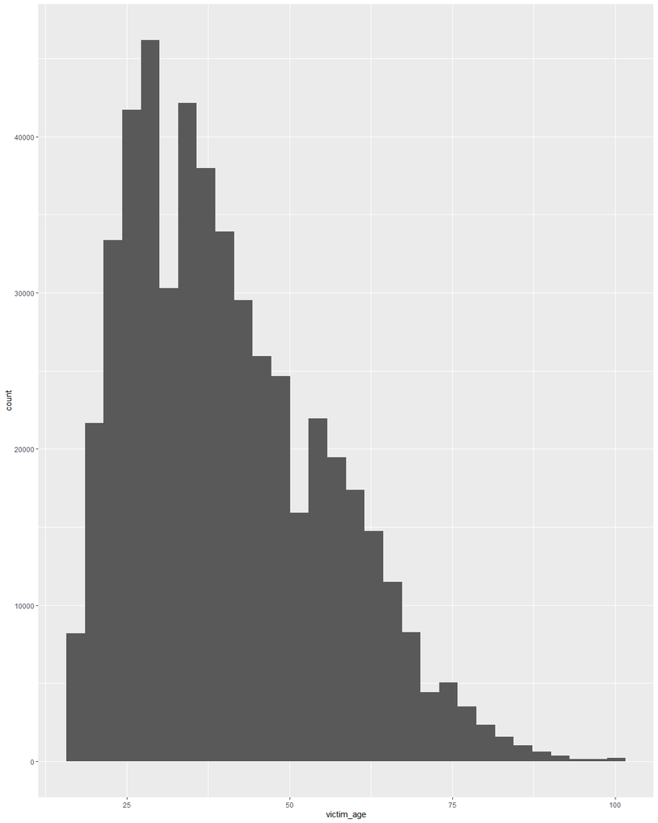

```r
amostra_tipos %>%
  ggplot(aes(x = victim_age)) + geom_histogram()
```

Em uma distribuição por tipo de crime conforme a seguir:

```r
amostra_tipos %>%
  group_by(crime_description) %>%
  count()
```

```
## # A tibble: 17 × 2
## # Groups:   crime_description [17]
##    crime_description                                            n
##    <chr>                                                    <int>
##  1 ASSAULT WITH DEADLY WEAPON, AGGRAVATED ASSAULT           45223
##  2 BATTERY - SIMPLE ASSAULT                                 64198
##  3 BRANDISH WEAPON                                          12528
##  4 BURGLARY                                                 33741
##  5 BURGLARY FROM VEHICLE                                    47396
##  6 CRIMINAL THREATS - NO WEAPON DISPLAYED                   16350
##  7 INTIMATE PARTNER - AGGRAVATED ASSAULT                    11460
##  8 INTIMATE PARTNER - SIMPLE ASSAULT                        41990
##  9 ROBBERY                                                  21979
## 10 THEFT FROM MOTOR VEHICLE - GRAND ($950.01 AND OVER)      26867
## 11 THEFT FROM MOTOR VEHICLE - PETTY ($950 & UNDER)          13729
## 12 THEFT OF IDENTITY                                        49779
## 13 THEFT PLAIN - PETTY ($950 & UNDER)                       34368
## 14 THEFT-GRAND ($950.01 & OVER)EXCPT,GUNS,FOWL,LIVESTK,PROD 20725
## 15 VANDALISM - FELONY ($400 & OVER, ALL CHURCH VANDALISMS)  36448
## 16 VANDALISM - MISDEAMEANOR ($399 OR UNDER)                 17063
## 17 VIOLATION OF RESTRAINING ORDER                           10303
```

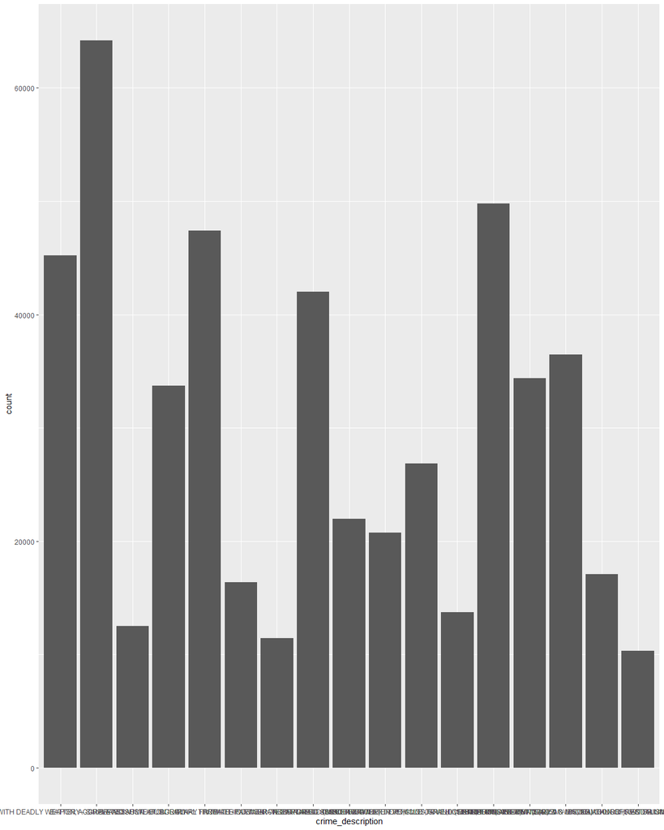

```r
amostra_tipos %>%
  ggplot(aes(x = crime_description)) + geom_bar()
```

E em uma distribuição por bairros conforme a seguir:

```r
amostra_tipos %>%
  group_by(area_name) %>%
  count()
```

```
## # A tibble: 21 × 2
## # Groups:   area_name [21]
##    area_name       n
##    <chr>       <int>
##  1 77th Street 33526
##  2 Central     35692
##  3 Devonshire  19547
##  4 Foothill    17233
##  5 Harbor      19771
##  6 Hollenbeck  17531
##  7 Hollywood   27700
##  8 Mission     20258
##  9 N Hollywood 24845
## 10 Newton      25008
## # ℹ 11 more rows
```

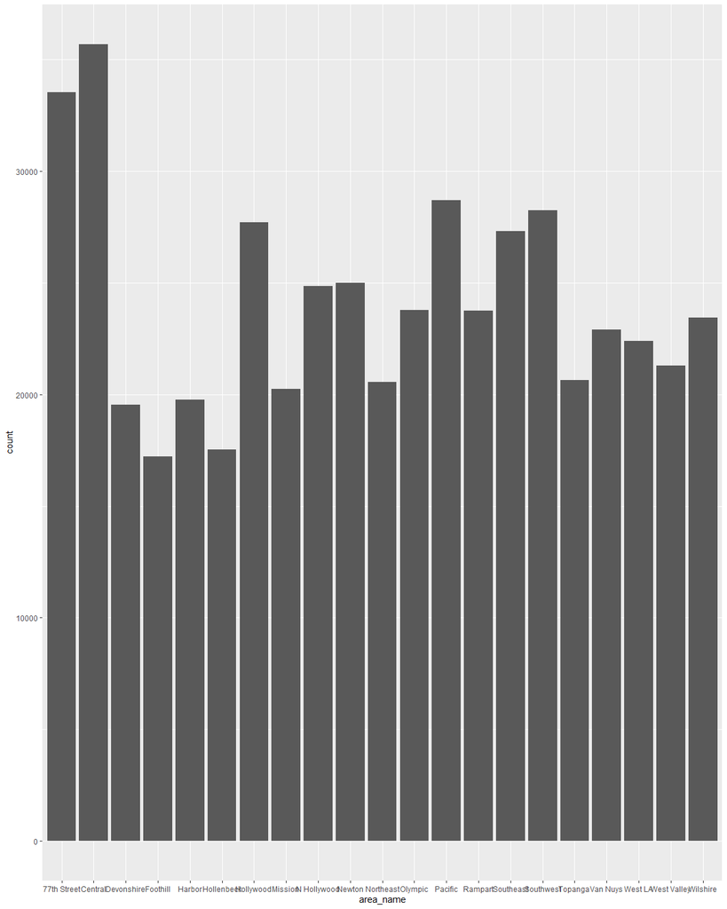

```r
amostra_tipos %>%
  ggplot(aes(x = area_name)) + geom_bar()
```

Realizado o tratamento necessário na base, podemos seguir com o nosso tutorial.

# Plano amostral AC1

Um plano amostral por conglomerado de uma etapa envolve a seleção de conglomerados como unidades primárias de amostragem. Um conglomerado é um grupo de elementos ou unidades dentro da população. A amostragem por conglomerado é frequentemente usada quando a população é grande e dispersa, tornando a amostragem de cada elemento impraticável.

No plano amostral por conglomerado de uma etapa:

- A população é dividida em conglomerados.
- Uma amostra de conglomerados é selecionada aleatoriamente.
- Todos os elementos dentro dos conglomerados selecionados compõem a amostra.

O objetivo é economizar custos e facilitar a coleta de dados, já que a amostragem é realizada em unidades de conglomerados em vez de indivíduos.

No caso desse tutorial, os conglomerados serão os bairros dos crimes.

## Parâmetros

Na estatística, um parâmetro é uma medida numérica que descreve uma característica de uma população e são usados para resumir e descrever aspectos importantes de uma população ou de uma amostra. Na população, parâmetros são valores numéricos que descrevem características específicas da população. No caso do nosso exemplo são os parâmetros de todos os crimes ocorridos em Los Angeles entre 2020 e 2023. Já no caso da amostra, são valores numéricos que descrevem características específicas de uma amostra retirada da população e são usados para fazer inferências sobre os parâmetros populacionais.

Os parâmetros são cruciais na inferência estatística, que envolve fazer afirmações ou inferências sobre uma população com base em informações de uma amostra. Quando se realiza uma inferência estatística, os parâmetros populacionais são frequentemente desconhecidos e são estimados usando os parâmetros amostrais.

Considerando a base tratada como nossa população, vamos realizar o cálculo dos parâmetros da população, para depois realizar o cálculo do tamanho da amostra.

```r
base_final <- amostra_tipos %>%
  select(area, area_name, crime_code, crime_description, victim_age, victim_sex, victim_descent) %>%
  mutate(area_name = as.factor(area_name),
         crime_description = as.factor(crime_description),
         victim_sex = as.factor(victim_sex))

congls <- base_final$area_name
```

```r
Balfas <- table(congls)

Bbarra <- mean(Balfas)

A <- length(Balfas)

N <- A*Bbarra
```

O total de observações na população:

$N =$ 5.04147^{5}

O número de conglomerados na população é:

$A =$ 21

O tamanho de cada um dos conglomerados:

33526, 35692, 19547, 17233, 19771, 17531, 27700, 20258, 24845, 25008, 20552, 23794, 28690, 23764, 27331, 28248, 20643, 22902, 22386, 21294, 23432

A média de observações por conglomerado:

$\bar{B} =$ 2.4007^{4}

Considerando a varíavel idade da vítima (`victim_age`) que o que queremos estimar nesse tutorial. Temos os seguintes parâmetros na população:

```r
#### Informando variavel de analise
variavel <- base_final$victim_age

#### Parametros gerais
# Media populacional
mi <- mean(variavel)

# Total populacional
totalp <- sum(variavel)

# Variancia populacional
sigma2 <- ((N-1)/N)*var(variavel)
```

A média de idade na população é: 40.6653337

O total da idade (soma de todas as idades) na população é: 2.0501306^{7}

E a variância populacional é: 223.5246342

Em relação aos conglomerados temos:

```r
#### Parametros por conglomerado
totais_congl <- tapply(variavel, congls, sum)
medias_congl <- tapply(variavel, congls, mean)

varpop <- function(x){
  var(x)*(length(x)-1)/length(x)
}

vars_congl <- tapply(variavel, congls, varpop)

# Media das medias
mibarra <- mean(medias_congl)

# Total medio
taubarra <- mean(totais_congl)

# Variancia dentro de conglomerados
sigma2dc <- sum((Balfas/Bbarra)*vars_congl)/A

# Variancia entre conglomerados
sigma2ec <- sum((Balfas/Bbarra)*(medias_congl-mi)^2)/A

sigmas <- sigma2dc + sigma2ec

# Variancia entre totais
var_totais <- varpop(totais_congl)
```

O total da idade por conglomerado:

1.33381^{6}, 1.390898^{6}, 8.46618^{5}, 7.20179^{5}, 8.22526^{5}, 7.06305^{5}, 1.063908^{6}, 8.12841^{5}, 1.018891^{6}, 9.60918^{5}, 8.60108^{5}, 9.36698^{5}, 1.201067^{6}, 9.18943^{5}, 1.067791^{6}, 1.123821^{6}, 8.79142^{5}, 9.6138^{5}, 9.8641^{5}, 9.23776^{5}, 9.65276^{5}

A média da idade por conglomerado:

39.7843465, 38.9694609, 43.3119149, 41.7906923, 41.6026503, 40.2889168, 38.408231, 40.1244447, 41.0099014, 38.4244242, 41.8503309, 39.3669833, 41.863611, 38.6695422, 39.0688595, 39.7840909, 42.587899, 41.9779932, 44.0637005, 43.3819855, 41.1947764

A variância da idade por conglomerado:

212.3827127, 188.3645274, 263.3000079, 224.6814848, 228.6356998, 216.396648, 192.3521922, 214.4660517, 219.7500328, 186.9382262, 219.6091679, 212.2646676, 226.9304047, 197.969951, 203.1415026, 240.8513229, 248.6397935, 221.408039, 278.2138463, 252.1896745, 228.4054729

A média das médias das idades dos conglomerados: 40.8345122

O total médio das idades dos conglomerados: 9.7625267^{5}

A variância dentro dos conglomerados: 220.7133967

A variância entre os conglomerados: 2.8112375

A soma da variância dentro dos conglomerados e da variância entre os conglomerados: 223.5246342

A variância entre os totais: 2.984597^{10}

## Cálculo do tamanho da amostra

Agora, realizaremos o cálculo do tamanho da amostra.

```r
epi.cluster1size = function (n, mean, var, epsilon.r, method = "mean", conf.level = 0.95)
{
  N. <- 1 - ((1 - conf.level)/2)
  z <- qnorm(N., mean = 0, sd = 1)
  if (method == "total") {
    Vsq <- var/mean^2
    numerator <- z^2 * n * Vsq
    denominator <- z^2 * Vsq + (n - 1) * epsilon.r^2
    rval <- round(numerator/denominator, digits = 0)
  }
  if (method == "mean") {
    Vsq <- var/mean^2
    numerator <- z^2 * n * Vsq
    denominator <- z^2 * Vsq + (n - 1) * epsilon.r^2
    rval <- round(numerator/denominator, digits = 0)
  }
  if (method == "mean.per.unit") {
    Vsq <- var/mean^2
    numerator <- z^2 * n * Vsq
    denominator <- z^2 * Vsq + (n - 1) * epsilon.r^2
    rval <- round(numerator/denominator, digits = 0)
  }
  if (method == "proportion") {
    if (length(var) != 2)
      stop("Error: var must be of length 2")
    if (length(mean) != 2)
      stop("Error: mean must be of length 2")
    rval <- "Not implemented yet!"
  }
  return(rval)
}
```

Utilizando os parâmetros calculados anteriormente: variância entre os totais, total médio das idades dos conglomerados, número de conglomerados na população. E esperando um erro não maior que 10% (erro relativo) e um intervalo de confiança de 99,73%, calculamos o número de conglomerados necessário.

```r
# A = qnt de bairros

A = 21
s2.entre.totais = var_totais
total.medio = taubarra
#sqrt(s2.entre.totais)/total.medio  #CV
conf = 0.9973
erro.rel = 0.1

tam_amostra <- epi.cluster1size(n = A, mean = total.medio, var = s2.entre.totais, epsilon = erro.rel,
                 method = "mean.per.unit", conf.level = conf)
```

Sendo assim, o número de conglomerados necessário para termos um erro relativo de 10% e um intervalo de confiança de 99,73% é de 12 (a).

Selecionando 12 bairros:

```r
a = 12
set.seed(2024)


am_cl = sampling::cluster(data = base_final, clustername = c("area_name"), a, method="srswor") # sem reposição
dados = getdata(base_final, am_cl)
n = dim(dados)[1]

dados <- dados %>%
  mutate(area_name = factor(area_name))
```

Os bairros selecionados para a amostra foram:

```r
levels(dados$area_name)
```

```
##  [1] "Central"     "Harbor"      "N Hollywood" "Newton"      "Northeast"
##  [6] "Pacific"     "Rampart"     "Southwest"   "Topanga"     "Van Nuys"
## [11] "West LA"     "Wilshire"
```

A frequência de crimes nos bairros selecionados:

```r
dados %>%
  group_by(area_name) %>%
  count()
```

```
## # A tibble: 12 × 2
## # Groups:   area_name [12]
##    area_name       n
##    <fct>       <int>
##  1 Central     35692
##  2 Harbor      19771
##  3 N Hollywood 24845
##  4 Newton      25008
##  5 Northeast   20552
##  6 Pacific     28690
##  7 Rampart     23764
##  8 Southwest   28248
##  9 Topanga     20643
## 10 Van Nuys    22902
## 11 West LA     22386
## 12 Wilshire    23432
```

# ANOVA de uma via

A ANOVA (Análise de Variância) de uma via é uma técnica estatística utilizada para comparar as médias de três ou mais grupos independentes em apenas uma variável independente. No caso, vamos realizar dois testes: uma para a variável `crime_description` e outro para a `victim_descent`.

Como temos um desenho amostral complexo, iremos realizar a função svydesign para criar um objeto de desenho amostral considerando os conglomerados.

```r
design <- svydesign(id=~area_name, data=dados, probs=~Prob, fpc=rep(A,n)) #probs = a/A pois selecao sem reposicao. #fpc necessario na sem reposicao.
```

Para calcular as médias da variável idade nos dados ponderados utilizamos a função `svymean`.

```r
svymean(~victim_age, design)
```

```
##              mean     SE
## victim_age 40.852 0.3307
```

Para calcular os totais da variável idade nos dados ponderado utilizamos a função `svytotal`.

```r
svytotal(~victim_age, design)
```

```
##               total     SE
## victim_age 21156415 638696
```

Para calcular as médias e os totais da variável idade nos dados ponderados por conglomerado utilizamos a função `svyby`.

```r
svyby(~victim_age, ~area_name, design = design, FUN = svymean)
```

```
##               area_name victim_age           se
## Central         Central   38.96946 1.207827e-15
## Harbor           Harbor   41.60265 3.297340e-15
## N Hollywood N Hollywood   41.00990 7.678367e-16
## Newton           Newton   38.42442 1.212831e-15
## Northeast     Northeast   41.85033 2.097320e-15
## Pacific         Pacific   41.86361 1.830089e-15
## Rampart         Rampart   38.66954 2.156941e-15
## Southwest     Southwest   39.78409 6.570937e-16
## Topanga         Topanga   42.58790 1.311668e-16
## Van Nuys       Van Nuys   41.97799 8.557780e-16
## West LA         West LA   44.06370 4.257242e-16
## Wilshire       Wilshire   41.19478 7.001949e-16
```

```r
svyby(~victim_age, ~area_name, design = design, FUN = svytotal)
```

```
##               area_name victim_age        se
## Central         Central    2434072 1593473.8
## Harbor           Harbor    1439421  942321.9
## N Hollywood N Hollywood    1783059 1167286.3
## Newton           Newton    1681607 1100869.9
## Northeast     Northeast    1505189  985377.5
## Pacific         Pacific    2101867 1375995.1
## Rampart         Rampart    1608150 1052781.5
## Southwest     Southwest    1966687 1287498.7
## Topanga         Topanga    1538499 1007183.7
## Van Nuys       Van Nuys    1682415 1101399.2
## West LA         West LA    1726218 1130074.6
## Wilshire       Wilshire    1689233 1105862.6
```

Utilizamos a função `svyglm` para ajustar um modelo de regressão linear generalizada (GLM) em dados ponderados por levantamento, no caso a amostra por conglomerado de uma etapa. Primeiro para a variável `crime_description` e depois para a variável `victim_descent`, conforme a seguir:

```r
m1 = svyglm(victim_age ~ crime_description, design = design)

summary(m1,df=degf(design))
```

```
##
## Call:
## svyglm(formula = victim_age ~ crime_description, design = design)
##
## Survey design:
## svydesign(id = ~area_name, data = dados, probs = ~Prob, fpc = rep(A,
##     n))
##
## Coefficients:
##                                                                            Estimate
## (Intercept)                                                               39.335604
## crime_descriptionBATTERY - SIMPLE ASSAULT                                  2.389088
## crime_descriptionBRANDISH WEAPON                                          -0.004173
## crime_descriptionBURGLARY                                                  7.535676
## crime_descriptionBURGLARY FROM VEHICLE                                    -1.157089
## crime_descriptionCRIMINAL THREATS - NO WEAPON DISPLAYED                    1.786143
## crime_descriptionINTIMATE PARTNER - AGGRAVATED ASSAULT                    -4.854445
## crime_descriptionINTIMATE PARTNER - SIMPLE ASSAULT                        -4.264303
## crime_descriptionROBBERY                                                  -0.801708
## crime_descriptionTHEFT-GRAND ($950.01 & OVER)EXCPT,GUNS,FOWL,LIVESTK,PROD  1.714612
## crime_descriptionTHEFT FROM MOTOR VEHICLE - GRAND ($950.01 AND OVER)       3.982256
## crime_descriptionTHEFT FROM MOTOR VEHICLE - PETTY ($950 & UNDER)           2.461640
## crime_descriptionTHEFT OF IDENTITY                                         2.999515
## crime_descriptionTHEFT PLAIN - PETTY ($950 & UNDER)                        1.441978
## crime_descriptionVANDALISM - FELONY ($400 & OVER, ALL CHURCH VANDALISMS)   2.757219
## crime_descriptionVANDALISM - MISDEAMEANOR ($399 OR UNDER)                  4.158151
## crime_descriptionVIOLATION OF RESTRAINING ORDER                            3.702304
##                                                                           Std. Error
## (Intercept)                                                                 0.224003
## crime_descriptionBATTERY - SIMPLE ASSAULT                                   0.234273
## crime_descriptionBRANDISH WEAPON                                            0.183143
## crime_descriptionBURGLARY                                                   0.587287
## crime_descriptionBURGLARY FROM VEHICLE                                      0.645203
## crime_descriptionCRIMINAL THREATS - NO WEAPON DISPLAYED                     0.251043
## crime_descriptionINTIMATE PARTNER - AGGRAVATED ASSAULT                      0.179686
## crime_descriptionINTIMATE PARTNER - SIMPLE ASSAULT                          0.166630
## crime_descriptionROBBERY                                                    0.192572
## crime_descriptionTHEFT-GRAND ($950.01 & OVER)EXCPT,GUNS,FOWL,LIVESTK,PROD   0.587867
## crime_descriptionTHEFT FROM MOTOR VEHICLE - GRAND ($950.01 AND OVER)        0.467175
## crime_descriptionTHEFT FROM MOTOR VEHICLE - PETTY ($950 & UNDER)            0.342385
```

[output cut: 52 more lines]

```
## crime_descriptionTHEFT FROM MOTOR VEHICLE - GRAND ($950.01 AND OVER)      ***
## crime_descriptionTHEFT FROM MOTOR VEHICLE - PETTY ($950 & UNDER)          ***
## crime_descriptionTHEFT OF IDENTITY                                        ***
## crime_descriptionTHEFT PLAIN - PETTY ($950 & UNDER)                       **
## crime_descriptionVANDALISM - FELONY ($400 & OVER, ALL CHURCH VANDALISMS)  ***
## crime_descriptionVANDALISM - MISDEAMEANOR ($399 OR UNDER)                 ***
## crime_descriptionVIOLATION OF RESTRAINING ORDER                           ***
## ---
## Signif. codes:  0 '***' 0.001 '**' 0.01 '*' 0.05 '.' 0.1 ' ' 1
##
## Zero or negative residual df; p-values not defined
##
## (Dispersion parameter for gaussian family taken to be 216.48)
##
## Number of Fisher Scoring iterations: 2
```

Nesse caso, verificamos que não há diferença da média da idade da vítima do tipo de crime BRANDISH WEAPON e BURGLARY FROM VEHICLE em relação a categoria de referência, ASSAULT WITH DEADLY WEAPON, AGGRAVATED ASSAULT.

```r
m2 = svyglm(victim_age ~ victim_descent, design = design)

summary(m2)
```

```
##
## Call:
## svyglm(formula = victim_age ~ victim_descent, design = design)
##
## Survey design:
## svydesign(id = ~area_name, data = dados, probs = ~Prob, fpc = rep(A,
##     n))
##
## Coefficients:
##                 Estimate Std. Error t value Pr(>|t|)
## (Intercept)      42.0319     0.6317  66.542 4.55e-11 ***
## victim_descentB  -1.6755     0.9972  -1.680 0.136789
## victim_descentH  -3.7871     0.5553  -6.820 0.000249 ***
## victim_descentO  -0.1705     0.6535  -0.261 0.801677
## victim_descentW   1.7785     0.6723   2.645 0.033169 *
## ---
## Signif. codes:  0 '***' 0.001 '**' 0.01 '*' 0.05 '.' 0.1 ' ' 1
##
## (Dispersion parameter for gaussian family taken to be 219.2834)
##
## Number of Fisher Scoring iterations: 2
```

No caso do teste para etnia da vítima, temos que não há diferença na idade das vítimas da etnia B (black) e O (other) em relação a etnia de referência, A (Asian). Sendo que há diferença para H (hispanic) e W (white), em relação a etnia A (Asian).

```r
regTermTest(m2,~victim_descent)
```

```
## Wald test for victim_descent
##  in svyglm(formula = victim_age ~ victim_descent, design = design)
## F =  103.2841  on  4  and  7  df: p= 2.6517e-06
```

O teste de Wald fornece evidências de que a variável etnia (victim_descent) tem um efeito significativo na idade das vítimas (victim_age). O p-valor sugere que a hipótese nula de que não há efeito significativo pode ser rejeitada.